```python
import pandas as pd
import numpy  as np
from numpy.random import RandomState,MT19937,SeedSequence ,seed,Generator,PCG64
import matplotlib.pyplot as M
import os
import scipy.stats as S
import seaborn as sns
from abc import ABC,abstractmethod
from statsmodels.stats import weightstats as WS
STYLES  = M.style.available
COLORS  = {
    'red':'red',
    'black':'black',
    'pink':'#E91E63',
    'indigo':'#3F51B5',
    'light_green':"#8BC34A",
    'light_blue':"#03A9F4",
    'deep_orange':"#FF5722",
    'light_orange':"#FF9800",
    'yellow':'#FFEB3B',
    'blue':'#2196F3'
}

PLOT_STYLES = {
    'default':{
        'figsize':(10,10),
        'axisbelow':True,
        'hist_color':COLORS['deep_orange'],
        'kde_color': COLORS['light_orange'],
        'mean_color':COLORS['blue'],
        'median_color':COLORS['light_green'],
        'kde_shade': True
    },
    'alternative0':{
        'figsize':(10,10),
        'axisbelow':True,
        'hist_color':COLORS['black'],
        'kde_color': COLORS['indigo'],
        'mean_color':COLORS['red'],
        'median_color':COLORS['yellow'],
        'kde_shade': True
    },
    'alternative1':{
        'figsize':(10,10),
        'axisbelow':True,
        'hist_color':COLORS['light_green'],
        'kde_color': COLORS['light_blue'],
        'mean_color':COLORS['light_orange'],
        'median_color':COLORS['yellow'],
        'kde_shade': True
    }
}
```

```python
def plotDataHistogram(**kwargs):
    X           = kwargs.get("X",[])
    Y           = kwargs.get("Y",[])
    _data       = merge(X,Y)
    data        = kwargs.get("data",_data)
    bandwidth   = kwargs.get("bandwidth",10)
    title       = kwargs.get('title','Data $\zeta$')
    bins        = kwargs.get('bins',300)
    show_kde    = kwargs.get('show_kde',False)
    show_hist   = kwargs.get('show_hist',False)
    show_mean   = kwargs.get('show_mean',False)
    show_median = kwargs.get('show_median',False)
    image_name  = kwargs.get("image_name",None)
    xLabel      = kwargs.get("xLabel","X = Avg. Response time($ART$)")
    style       = kwargs.get("style",{
                'figsize':(10,10),
                'axisbelow':True,
                'hist_color':COLORS['deep_orange'],
                'kde_color': COLORS['light_orange'],
                'mean_color':COLORS['blue'],
                'median_color':COLORS['light_green'],
                'kde_shade': True
    })
    ax          = kwargs.get('ax')
    if(not ax):
        _,ax = M.subplots(figsize=style['figsize'])

    ax.set_title(title)
    ax.set_xlabel(xLabel)
    ax.set_ylabel("$Density$")
#
    data_df = pd.DataFrame(data)
    if(show_hist):
        data_df[0].plot.hist(density=1,bins=bins,color=style['hist_color'],ax=ax,label=title)
    if(show_kde):
        sns.kdeplot(data,
                    color=style['kde_color'],
                    shade=style['kde_shade'],
                    ax=ax,
                    label="Kernel Density Estimation($KDE$)",
                    bw_adjust = bandwidth
                   )
#         data_df[0].plot.density(ax=ax,color="red",label="Kernel Density Estimation(KDE)")

#   GRID STYLE
    ax.set_axisbelow(style['axisbelow'])
    M.grid(color="white")
    ax.yaxis.grid(color='white', linestyle='dashed')
#   END GRID STYLE
    if(show_mean):
        ax.axvline(data.mean(),ymin=0,ymax=1,color=style['mean_color'],label="Mean($\\bar{X}$)")
    if(show_median):
        ax.axvline(np.median(data),ymin=0,ymax=1,color=style['median_color'],label="Median(X)")
#     sns.kdeplot(data=data,ax=ax,color="red")
#     hist,bins = np.histogram(data)
#     ax.hist(hist,bins=bins,density=True,color="blue")
#     print(hist,bins)
    M.legend()
    if(image_name):
        M.savefig(image_name,dpi=300)
#     M.show()
    return ax
```

# Synthetic Data

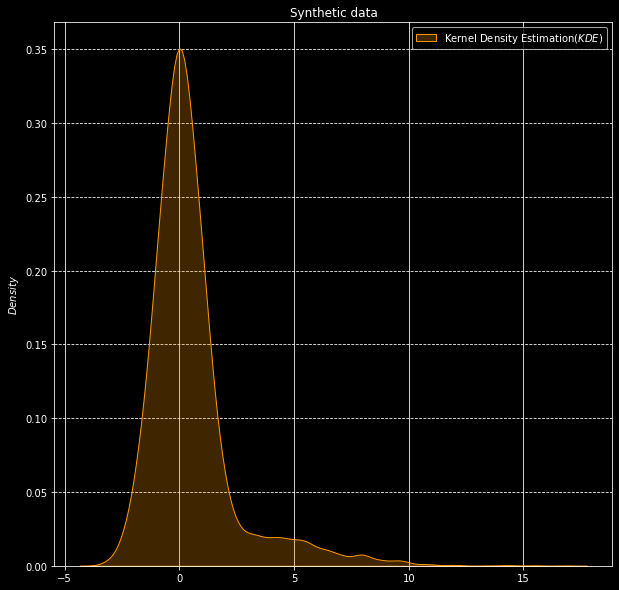

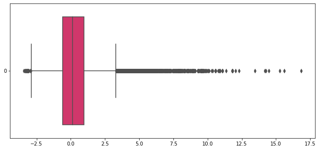

```python
# with M.style.context(STYLES[22]):
with M.style.context("dark_background"):
#
    norm   = NormalDistribution(loc=0,scale=1)
    erlang = ErlangDistribution(loc=0,scale=1,a=5)
    _,data   = generateFractionSample(size=10000,distributions=[norm,erlang],fractions= [0.90,.10])
#     data   = generateFractionSample(size=10000,distributions=[norm])
#     print(data.mean(),np.median(data),np.std(data))
    title           = "Synthetic data"
    ax = plotDataHistogram(
        data=data,
        title=title,
        show_kde=True,
        show_hist=False,
        show_mean=not True,
        show_median=not True,
        bins=200,
        bandwidth= 1,
#         image_name="normal_kde",
        xLabel =""
    )
    M.show()
_,ax = M.subplots(figsize=(11,5))
sns.boxplot(data=data,color=COLORS['pink'],orient='h',ax=ax)
#     print(data.mean())
```

## Hypothesis Testing

### Z-test

A z-test is a statistical test used to determine whether two population means are different when the variances are known and the sample size is large.

Use a Z test only if you match the following conditions:

- The sample size is greater than 30. Otherwise use a T-test.
- The data points must be independent from each other.
- Data should be normally distributed.
- Data must be select using a probabilistic sampling method.

Two-sample Z test- In two sample z-test , similar to t-test here we are checking two independent data groups and deciding whether sample mean of two group is equal or not.

```python
norm    = NormalDistribution(loc=0,scale=1)
ztest0  = ZTest(alpha=0.05)
group0  =norm.sample(size =1000,loc=100,scale=1)
group1  =norm.sample(size =100,loc=100,scale=1)
group2  =norm.sample(size =1000,loc=10,scale=1)
# ztest0.test(x1 =s100,x2=None,value=101,alternative="smaller")
# ztest0.test(x1 =s100,value=100,alternative="larger")
# ztest0.test(x1 =group0,x2=group1,alternative="two-sided")
```

## T-test

A t-test is a statistical test that is used to compare the means of two groups. It is often used in hypothesis testing to determine whether a process or treatment actually has an effect on the population of interest, or whether two groups are different from one another.

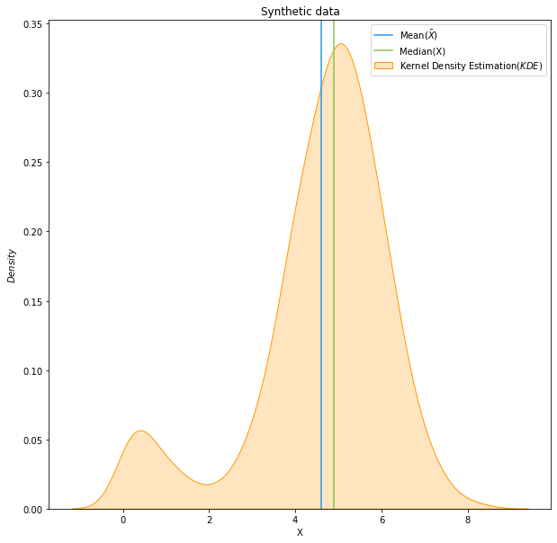

```python
norm   = NormalDistribution(loc=5,scale=1)
erlang = ErlangDistribution(loc=0,scale=1,a=1)
_,data   = generateFractionSample(size=1000,distributions=[norm,erlang],fractions=[.90,.10])
plotDataHistogram(
    data        = data,
    show_kde    = True,
    show_hist   = False,
    show_mean   = True,
    show_median = True,
    bins        = 200,
    bandwidth   = 1,
    title       = "Synthetic data",
    xLabel      = "X",
    image_name  = "synthetic_data"
)
M.show()
```

```python
ttest0 = TTest(alpha=0.05)
# print(data.mean())
ttest0.test(data=data,mean=5.4)
```

[output not shown]

### ANOVA

ANOVA, which stands for Analysis of Variance, is a statistical test used to analyze the difference between the means of more than two groups.

- $H_{o} \to \mu_{i} = \mu_{i} \text{ for all i} \neq \text{i}$
- $H_{A} \to \mu_{i} \neq \mu_{i} \text{ for all i }\neq \text{i}$

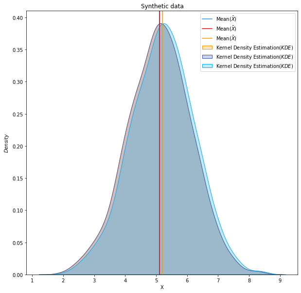

```python
norm   = NormalDistribution()
# erlang = ErlangDistribution(loc=0,scale=1,a=1)
data   =[
    norm.sample(size=1000,loc=5.1,scale=1),
    norm.sample(size=1000,loc=5.1,scale=1),
    norm.sample(size=1000,loc=5.2,scale=1),
]
# _,ax0 =  M.subplots(figsize=(10,10))
plot_parameters = [
    {
        'data'        : data[0],
        'show_kde'    : True,
        'show_hist'   : False,
        'show_mean'   : True,
        'show_median' : not True,
        'bins'        : 200,
        'bandwidth'   : 1,
        'title'       : "Synthetic data",
        'xLabel'      : "X",
        'style'       : PLOT_STYLES['default'],
    },
    {
        'data'        : data[1],
        'show_kde'    : True,
        'show_hist'   : False,
        'show_mean'   : True,
        'show_median' : not True,
        'bins'        : 200,
        'bandwidth'   : 1,
        'title'       : "Synthetic data",
        'xLabel'      : "X",
        'style'       : PLOT_STYLES['alternative0'],
    },
    {
        'data'        : data[2],
        'show_kde'    : True,
        'show_hist'   : False,
        'show_mean'   : True,
        'show_median' : not True,
        'bins'        : 200,
        'bandwidth'   : 1,
        'title'       : "Synthetic data",
        'xLabel'      : "X",
        'style'       : PLOT_STYLES['alternative1'],
    }
]
_,ax = M.subplots(figsize=(10,10))
for plot_params in plot_parameters:
    plot_params['ax']=ax
    plotDataHistogram(**plot_params)

M.show()
```

```python
fTest = FTest(alpha=.01)
fTest.test(data=data)
```

```
NULL HYPOTHESIS(H0) [ACCEPTED]
```

```
{'F_SCORE': 3.230802907559575, 'P_VALUE': 0.03966345436448154}
```

# Exercise 3

### Data

Data is generated from 5 probability distributions: Erlang, Laplace, Pareto, Exponential and Gamma distribution.

```python
erlang  = ErlangDistribution(a=10,loc=0,scale=1)
laplace = LaplaceDistribution(loc=5,scale=1)
pareto  = ParetoDistribution(b=10,loc=0,scale=1)
expon   = ExponentialDistribution(loc=0,scale=1)
gamma   = GammaDistribution(a=11,loc=0,scale=1)
raw_data , data= generateFractionSample(
    size=5000,
    distributions = [
                    erlang,
                     laplace,
                     pareto,
                     expon,
                     gamma
                    ]
)
raw_data0,data0 = generateFractionSample(size=5000,distributions=[
    pareto,
    pareto,
    pareto,
    pareto,
    pareto,
])
# data
```

### Plot data

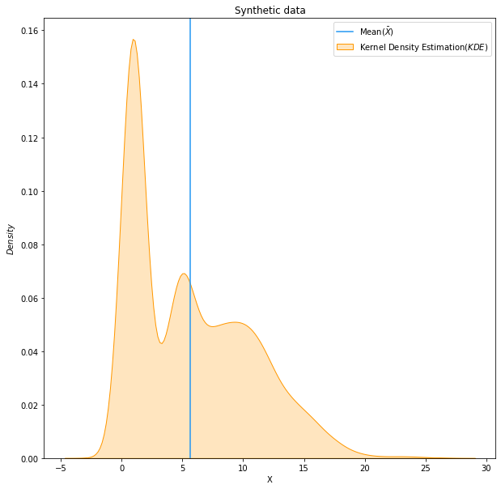

```python
plotDataHistogram(
    data        = data,
    show_kde    = True,
    show_hist   = not True,
    show_mean   = True,
    show_median = not True,
    bins        = 200,
    bandwidth   = 1,
    title       = "Synthetic data",
    xLabel      = "X",
    image_name  = "ex2"
)
M.show()
```

### Kruskal-Wallis

The Kruskal-Wallis H test (sometimes also called the "one-way ANOVA on ranks") is a rank-based nonparametric test that can be used to determine if there are statistically significant differences between two or more groups of an independent variable on a continuous or ordinal dependent variable. It is considered the nonparametric alternative to the one-way ANOVA, and an extension of the Mann-Whitney U test to allow the comparison of more than two independent groups.

- $H_{o} \to Me_{i} = Me_{i} \text{ for all i }\neq \text{ i}$

```python
kruskal = KruskalWallisTest(alpha=0.05)
kruskal.test(data=raw_data)
# kruskal.test(data=raw_data0)
```

```
NULL HYPOTHESIS(H0) [REJECTED]
```

```
{'KRUSKAL_WALLIS_SCORE': 4207.196259586803, 'P_VALUE': 0.0}
```

### Mann-Whitney U Test

The Mann-Whitney U test is a nonparametric test of the null hypothesis that the distribution underlying sample x is the same as the distribution underlying sample y. It is often used as a test of difference in location between distributions.

```python
mann = MannWhitneyuTest(alpha=0.05)
mann.test(data = raw_data[:2])
# mann.test(data = raw_data0[:2])
```

```
NULL HYPOTHESIS(H0) [REJECTED]
```

```
{'MANN_WHITENEY_U_SCORE': 0.0, 'P_VALUE': 2.9281214567494703e-165}
```

### Wilcoxon signed rank test

The Wilcoxon signed-rank test tests the null hypothesis that two related paired samples come from the same distribution. In particular, it tests whether the distribution of the differences x - y is symmetric about zero. It is a non-parametric version of the paired T-test.

```python
expon0   = ExponentialDistribution(loc=6,scale=2)
norm0    = NormalDistribution(loc=51,scale=2)
norm1     = NormalDistribution(loc=51,scale=2.1)
raw_data,data = generateFractionSample(size=1000,
    distributions=[
        norm0,
#         norm1,
        expon0

    ]

)
```

```python
wilcoxon = WilcoxonSignedRankTest(alpha=0.05)
wilcoxon.test(data=raw_data)
# S.wilcoxon(raw_data[0],raw_data[1])
```

```
NULL HYPOTHESIS(H0) [REJECTED]
```

```
{'WILCOXON_SIGNED_RANK_SCORE': 0.0, 'P_VALUE': 1.2647189486921487e-83}
```

## Storage system

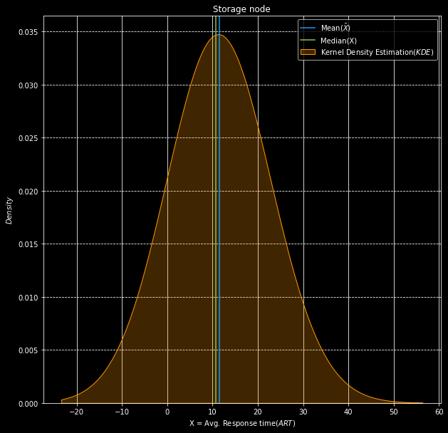

```python
with M.style.context("dark_background"):
#     _,ax = plt.subplots(figsize=(10,10))
#     ax.set_xlabel("Avg. Service time($AST$)")
    folder_path = "./wl_peers_3"
    _,SN = getSortedFileNames(folder_path)
    responseTimes = np.array([])
    data = readCSV(folder_path =folder_path ,
                       filename=SN[1],
                       names=["D0","D1","D2","D3","D4","D5","D6"]
                  )
    servicesTimes,AVG_ST= getST(data,cmds =["REPLICATION","REPLICA_SAVED_SUCCESSFULLY"],step=33,column="ARRIVAL_TIME")
#     print(servicesTimes.median())
#   Style
    title = "Storage node"
    ax = plotDataHistogram(
                      data=servicesTimes,
                      title=title,
                      show_kde=True,
                      show_hist=False,
                      show_median=True,
                      show_mean=True,
                      bins=10,
                     )
#     print(servicesTimes)
#     sns.boxplot(data=servicesTimes[servicesTimes<=15])
#     plt.savefig("dis.png",dpi=300)
#     print(servicesTimes.shape[0])
#     sns.kdeplot(data=servicesTimes,fill=True,ax=ax,color="red")
```

# Utils

```python
class HypothesisTesting(ABC):
    def __init__(self,**kwargs):
        self.alpha = kwargs.get("alpha",0.05)
        self.data  = kwargs.get('data',[])
    @abstractmethod
    def test(self,**kwargs):
        pass
    @staticmethod
    def checkPvalue(pvalue,alpha):
        if(pvalue < alpha):
            print("NULL HYPOTHESIS(H0) [REJECTED]")
        else:
            print("NULL HYPOTHESIS(H0) [ACCEPTED]")

class ZTest(HypothesisTesting):
    def __init__(self,**kwargs):
        super().__init__(**kwargs)
    def test(self,**kwargs):
        alpha       = kwargs.get('alpha',self.alpha)
        x1          = kwargs.get('x1')
        x2          = kwargs.get('x2',None)
        mean        = kwargs.get('value',0)
        ddof        = kwargs.get('ddof',1)
        alternative = kwargs.get('alternative','two-sided')
        tstat,pvalue= WS.ztest(x1=x1,x2=x2,value=mean,alternative=alternative)
#         print(tstat,pvalue)
        HypothesisTesting.checkPvalue(pvalue,alpha)
#         if(pvalue < alpha):
#             print("NULL HYPOTHESIS(H0) [REJECTED]")
#         else:
#             print("NULL HYPOTHESIS(H0) [ACCEPTED]")
        return {'Z_SCORE':tstat,'P_VALUE':pvalue}


class TTest(HypothesisTesting):
    def __init__(self,**kwargs):
        super().__init__(**kwargs)
    def test(self,**kwargs):
        alpha = kwargs.get('alpha',self.alpha)
        data  = kwargs.get('data',self.data)
        mean  = kwargs.get('mean',0)
        result = S.ttest_1samp(data,mean)
        HypothesisTesting.checkPvalue(result[1],alpha)
#         if(result[1] < alpha):
#             print("NULL HYPOTHESIS(H0) [REJECTED]")
#         else:
#             print("NULL HYPOTHESIS(H0) [ACCEPTED]")
#         return result
class FTest(HypothesisTesting):
    def __init__(self,**kwargs):
        super().__init__(**kwargs)
    def test(self,**kwargs):
        data = kwargs.get('data',[])
        alpha = kwargs.get('alpha',self.alpha)
        fscore , pvalue = S.f_oneway(*data)
        HypothesisTesting.checkPvalue(pvalue,alpha)
        return {'F_SCORE':fscore,'P_VALUE':pvalue}
class  KruskalWallisTest(HypothesisTesting):
    def __init__(self,**kwargs):
        super().__init__(**kwargs)
    def test(self,**kwargs):
        data  = kwargs.get('data',self.data)
        alpha = kwargs.get('alpha',self.alpha)
        statistic,pvalue = S.kruskal(data)
        HypothesisTesting.checkPvalue(pvalue,alpha)
        return {'KRUSKAL_WALLIS_SCORE': statistic,'P_VALUE':pvalue}

class  KruskalWallisTest(HypothesisTesting):
    def __init__(self,**kwargs):
        super().__init__(**kwargs)
    def test(self,**kwargs):
        data  = kwargs.get('data',self.data)
        alpha = kwargs.get('alpha',self.alpha)
        statistic,pvalue = S.kruskal(*data)
        HypothesisTesting.checkPvalue(pvalue,alpha)
        return {'KRUSKAL_WALLIS_SCORE': statistic,'P_VALUE':pvalue}
class  MannWhitneyuTest(HypothesisTesting):
    def __init__(self,**kwargs):
        super().__init__(**kwargs)
    def test(self,**kwargs):
        data  = kwargs.get('data',self.data)
        alpha = kwargs.get('alpha',self.alpha)
        res   = S.mannwhitneyu(*data)
#         print(res)

        HypothesisTesting.checkPvalue(res.pvalue,alpha)
        return {'MANN_WHITENEY_U_SCORE':res.statistic,'P_VALUE':res.pvalue}

class WilcoxonSignedRankTest(HypothesisTesting):
    def __init__(self,**kwargs):
        super().__init__(**kwargs)
    def test(self,**kwargs):
        data  = kwargs.pop('data',self.data)
        alpha = kwargs.pop('alpha',self.alpha)
        statistic,pvalue   = S.wilcoxon(*data,**kwargs)
        HypothesisTesting.checkPvalue(pvalue,alpha)
        return {'WILCOXON_SIGNED_RANK_SCORE':statistic,'P_VALUE':pvalue}
```

```python
class Continuous(ABC):
    def __init__(self,**kwargs):
        self.distribution = kwargs.pop('distribution')
        self.parameters   = kwargs
    @abstractmethod
    def sample(**kwargs):
        pass
    def mean(self,**kwargs):
        parameters = kwargs or self.parameters
        print(parameters)
        return self.distribution.mean(**parameters)
    def std(self,**kwargs):
        parameters = kwargs or self.parameters
        return self.distribution.std(**parameters)
    def variance(self,**kwargs):
        parameters = kwargs or self.parameters
        return self.distribution.var(**parameters)
    def median(self,**kwargs):
        parameters = kwargs or self.parameters
        return self.distribution.median(**parameters)

class NormalDistribution(Continuous):
    def __init__(self,**kwargs):
        super().__init__(**kwargs,**{'distribution':S.norm})
    def sample(self,**kwargs):
        random_state = kwargs.pop("random_state",Generator(PCG64(12345)))
        size         = kwargs.pop('size',100)
        parameters   = kwargs or self.parameters
        return self.distribution.rvs(size=size,**parameters,random_state=random_state)

class ErlangDistribution(Continuous):
    def __init__(self,**kwargs):
        super().__init__(**kwargs,**{'distribution':S.erlang})
    def sample(self,size,**kwargs):
        random_state = kwargs.get("random_state",Generator(PCG64(12345)))
        return self.distribution.rvs(size=size,**self.parameters,random_state=random_state)

class ExponentialDistribution(Continuous):
    def __init__(self,**kwargs):
        super().__init__(**kwargs,**{'distribution':S.expon})
    def sample(self,size,**kwargs):
        random_state = kwargs.get("random_state",Generator(PCG64(12345)))
        return self.distribution.rvs(size=size,**self.parameters,random_state=random_state)
class ParetoDistribution(Continuous):
    def __init__(self,**kwargs):
        super().__init__(**kwargs,**{'distribution':S.pareto})
    def sample(self,size,**kwargs):
        random_state = kwargs.get("random_state",Generator(PCG64(12345)))
        return self.distribution.rvs(size=size,**self.parameters,random_state=random_state)
class GammaDistribution(Continuous):
    def __init__(self,**kwargs):
        super().__init__(**kwargs,**{'distribution':S.gamma})
    def sample(self,size,**kwargs):
        random_state = kwargs.get("random_state",Generator(PCG64(12345)))
        return self.distribution.rvs(size=size,**self.parameters,random_state=random_state)
class BetaDistribution(Continuous):
    def __init__(self,**kwargs):
        super().__init__(**kwargs,**{'distribution':S.beta})
    def sample(self,size,**kwargs):
        random_state = kwargs.get("random_state",Generator(PCG64(12345)))
        return self.distribution.rvs(size=size,**self.parameters,random_state=random_state)
class CauchyDistribution(Continuous):
    def __init__(self,**kwargs):
        super().__init__(**kwargs,**{'distribution':S.cauchy})
    def sample(self,size,**kwargs):
        random_state = kwargs.get("random_state",Generator(PCG64(12345)))
        return self.distribution.rvs(size=size,**self.parameters,random_state=random_state)
class LaplaceDistribution(Continuous):
    def __init__(self,**kwargs):
        super().__init__(**kwargs,**{'distribution':S.laplace})
    def sample(self,size,**kwargs):
        random_state = kwargs.get("random_state",Generator(PCG64(12345)))
        return self.distribution.rvs(size=size,**self.parameters,random_state=random_state)
```

```python
def generateFractionSample(**kwargs):
    distributions = kwargs.get('distributions',[])
    size          = kwargs.get('size',1000)
    lenDist       = len(distributions)
    fractions     = kwargs.get('fractions',[1/lenDist]*lenDist)
    totalFrac     = sum(fractions)
#     print(fractions,sum(fractions))
    if(lenDist == 0): raise Exception("No distributions")
    elif(not totalFrac == 1): raise Exception("The sum of the fractions must be equal to one")
    data = np.array([])
    raw_data = []
    for fraction,distribution in zip(fractions,distributions):
        sample = distribution.sample(size = int(size*fraction))
        data  = np.append(data,sample)
        raw_data.append(sample)

    return raw_data,data
#


def merge(x,y):
    return np.append(x,y)
MAX_EXPERIMENTS = 50

def calculateAVGServiceTime(start,end):
    return (end-start).mean()
def getSortedFileNames(folder_path):
    files = os.listdir(folder_path)
    cs = list(filter(lambda x:x.startswith("cs"),files))
    sn = list(filter(lambda x:x.startswith("sn"),files))
    cs.sort(key = lambda x: int(x.split("_")[0].split("-")[1]))
    sn.sort(key = lambda x : int( x.split("-")[1] ))
    return cs,sn

def readCSV(**kwargs):
    mandatory_names = ["ARRIVAL_TIME","NODE_ID","RELATIVE_TIME","LOG_LEVEL","THREAD","COMMAND"]
    default_names   = ["D0","D1","D2"]
    folder_path     = kwargs.get("folder_path")
    filename        = kwargs.get("filename",None)
    if not filename: raise Exception("NO FILENAME")
    names = mandatory_names+kwargs.get("names",default_names)
    return pd.read_csv("{}/{}".format(folder_path,filename),header=None,sep=" ",names=names)
def getDataByCommand(data,cmd,**kwargs):
    reset_index  = kwargs.get("reset_index",True)
    D = data[data["COMMAND"]==cmd]
    if(reset_index):
        return D.reset_index(drop=True)
    else:
        return D

def getST(data,**kwargs):
    cmds      = kwargs.get("cmds",[])
    time_col  =  kwargs.get("column","ARRIVAL_TIME")
    step      = kwargs.get("step",11)
#
    if not (len(cmds) == 2) : raise Exception("NO CMDS ")
    UFCS = getDataByCommand( data, cmds[1])
    RUN  = getDataByCommand(data,cmds[0])
    STs  = np.array([])
    for i in range(MAX_EXPERIMENTS):
        mask = [(step*i),(i+1)*step]
        ufcs = UFCS[mask[0]:mask[1]]
        run  = RUN[mask[0]:mask[1]]
        st = calculateAVGServiceTime(run[time_col],ufcs[time_col])
        STs = np.append(STs,[st])
    STs = STs[~np.isnan(STs)]
    return STs,STs.mean()
```

```python
# {'AA':2} or {}
```

## Storage nodes

### 3 nodes

```python
folder_path = "./wl_peers_3"
def showStorageNodeMetrics(folder_path):
    _,SN = getSortedFileNames(folder_path)
    responseTimes = np.array([])
    for  i in range(len(SN)-1):
        print("Storage node[{}]".format(i))
        data = readCSV(folder_path =folder_path ,
                       filename=SN[i],
                       names=["D0","D1","D2","D3","D4","D5","D6"]
                      )
        servicesTimes,AVG_ST= getST(data,cmds =["REPLICATION","REPLICA_SAVED_SUCCESSFULLY"],step=33,column="ARRIVAL_TIME")
        rt = servicesTimes.sum()
        responseTimes = np.append(responseTimes,[rt])
        print("Response time = {} ms\nAvg. Service time: {} ms\nn: {}".format(
            rt,
            AVG_ST,
            servicesTimes.shape[0]
        ))
        print("_"*50)
    print("Avg. Response time: {}".format(responseTimes.mean()))
showStorageNodeMetrics(folder_path)
```

```
Storage node[0]
Response time = 617.2727272727274 ms
Avg. Service time: 12.345454545454547 ms
n: 50
__________________________________________________
Storage node[1]
Response time = 573.4848484848484 ms
Avg. Service time: 11.469696969696967 ms
n: 50
__________________________________________________
Avg. Response time: 595.3787878787879
```

```python
def showStorageNodeLeaderMetrics(folder_path):
    _,SN = getSortedFileNames(folder_path)
    leader_data = readCSV(folder_path=folder_path,filename=SN[-1],names=["D0","D1","D2","D3","D4","D5","D6"])
    lastCmd = "SENT_REPLICATION_CMD"
    cmds = [("SAVE_FILE_INIT","SAVE_FILE_DONE","SAVE_FILE"),("COMPRESSION_INIT","COMPRESSION_DONE","COMPRESSION")]

    for init,done,title in cmds:
        servicesTimes,avg_st = getST(leader_data,cmds =[init,done],step=33,column="ARRIVAL_TIME")
        print(title)
        print("Avg. Service time: {}\nResponse time: {}".format(avg_st,servicesTimes.sum()))
        print("_"*50)
    servicesTimes,avg_st = getST(leader_data,cmds =["UPLOAD_FILE",lastCmd],step=33,column="ARRIVAL_TIME")
    print("TOTAL")
    print("Avg. Service time: {}\nResponse time: {}".format(avg_st,servicesTimes.sum()))


showStorageNodeLeaderMetrics(folder_path)
```

```
SAVE_FILE
Avg. Service time: 12.59818181818182
Response time: 629.909090909091
__________________________________________________
COMPRESSION
Avg. Service time: 19.80060606060606
Response time: 990.0303030303031
__________________________________________________
TOTAL
Avg. Service time: 34.22969696969697
Response time: 1711.4848484848485
```

### 6 nodes

```python
folder_path = "./wl_peers_6"
showStorageNodeLeaderMetrics(folder_path)
```

```
SAVE_FILE
Avg. Service time: 25.284848484848485
Response time: 1264.2424242424242
__________________________________________________
COMPRESSION
Avg. Service time: 263.9273863636364
Response time: 13196.36931818182
__________________________________________________
TOTAL
Avg. Service time: 291.35058712121213
Response time: 14567.529356060606
```

```python
showStorageNodeMetrics(folder_path)
```

```
Storage node[0]
Response time = 316.4848484848485 ms
Avg. Service time: 15.824242424242424 ms
n: 20
__________________________________________________
Storage node[1]
Response time = 392.539393939394 ms
Avg. Service time: 19.626969696969702 ms
n: 20
__________________________________________________
Storage node[2]
Response time = 316.83333333333337 ms
Avg. Service time: 15.087301587301589 ms
n: 21
__________________________________________________
Storage node[3]
Response time = 486.55327468230695 ms
Avg. Service time: 24.327663734115347 ms
n: 20
__________________________________________________
Storage node[4]
Response time = 327.939393939394 ms
Avg. Service time: 15.61616161616162 ms
n: 21
__________________________________________________
Avg. Response time: 368.0700488758554
```

### 9 nodes

```python
folder_path = "./wl_peers_9"
showStorageNodeLeaderMetrics(folder_path)
```

```
SAVE_FILE
Avg. Service time: 30.52845528455284
Response time: 1251.6666666666665
__________________________________________________
COMPRESSION
Avg. Service time: 19.487527716186257
Response time: 798.9886363636365
__________________________________________________
TOTAL
Avg. Service time: 51.21590909090909
Response time: 2099.852272727273
```

```python
showStorageNodeMetrics(folder_path)
```

```
Storage node[0]
Response time = 302.0419580419581 ms
Avg. Service time: 23.233996772458315 ms
n: 13
__________________________________________________
Storage node[1]
Response time = 308.44848484848484 ms
Avg. Service time: 23.726806526806527 ms
n: 13
__________________________________________________
Storage node[2]
Response time = 333.5484848484848 ms
Avg. Service time: 25.657575757575753 ms
n: 13
__________________________________________________
Storage node[3]
Response time = 312.2668997668998 ms
Avg. Service time: 24.020530751299987 ms
n: 13
__________________________________________________
Storage node[4]
Response time = 312.6565656565657 ms
Avg. Service time: 24.050505050505055 ms
n: 13
__________________________________________________
Storage node[5]
Response time = 310.56060606060606 ms
Avg. Service time: 23.88927738927739 ms
n: 13
__________________________________________________
Storage node[6]
Response time = 280.6363636363637 ms
Avg. Service time: 21.58741258741259 ms
n: 13
__________________________________________________
Storage node[7]
Response time = 263.39393939393943 ms
Avg. Service time: 23.944903581267223 ms
n: 11
__________________________________________________
Avg. Response time: 302.9441627816628
```

### 12 nodes

```python
folder_path = "./wl_peers_12"
showStorageNodeLeaderMetrics(folder_path)
```

```
SAVE_FILE
Avg. Service time: 34.82787878787879
Response time: 1741.3939393939393
__________________________________________________
COMPRESSION
Avg. Service time: 1104.3441287878786
Response time: 55217.206439393936
__________________________________________________
TOTAL
Avg. Service time: 1141.3973484848484
Response time: 57069.867424242424
```

```python
# folder_path = "./wl_peers_12"
showStorageNodeMetrics(folder_path)
```

```
Storage node[0]
Response time = 498.030303030303 ms
Avg. Service time: 49.8030303030303 ms
n: 10
__________________________________________________
Storage node[1]
Response time = 326.3484848484848 ms
Avg. Service time: 32.63484848484848 ms
n: 10
__________________________________________________
Storage node[2]
Response time = 290.69696969696963 ms
Avg. Service time: 29.069696969696963 ms
n: 10
__________________________________________________
Storage node[3]
Response time = 317.3636363636364 ms
Avg. Service time: 31.736363636363638 ms
n: 10
__________________________________________________
Storage node[4]
Response time = 219.5151515151515 ms
Avg. Service time: 21.95151515151515 ms
n: 10
__________________________________________________
Storage node[5]
Response time = 213.0909090909091 ms
Avg. Service time: 21.30909090909091 ms
n: 10
__________________________________________________
Storage node[6]
Response time = 298.78787878787875 ms
Avg. Service time: 29.878787878787875 ms
n: 10
__________________________________________________
Storage node[7]
Response time = 248.93939393939394 ms
Avg. Service time: 24.893939393939394 ms
n: 10
__________________________________________________
Storage node[8]
Response time = 211.63636363636365 ms
Avg. Service time: 21.163636363636364 ms
n: 10
__________________________________________________
Storage node[9]
Response time = 277.3636363636364 ms
Avg. Service time: 27.736363636363638 ms
n: 10
__________________________________________________
Storage node[10]
Response time = 186.06060606060603 ms
Avg. Service time: 18.606060606060602 ms
n: 10
__________________________________________________
Avg. Response time: 280.7121212121212
```

### Avg. Arrival time

```python
run_data = nodes3_data[nodes3_data["COMMAND"]=="RUN"].reset_index(drop=True)
```

[output not shown]

```python
def calculateAVGArrivalTime(xs):
    denominator = np.diff(xs).sum()
    return denominator/run_data["ARRIVAL_TIME"].shape[0]
calculateAVGArrivalTime(run_data["ARRIVAL_TIME"])
```

### Avg. Service time

```python
upload_sent_data = nodes3_data[nodes3_data["COMMAND"]=="UPLOAD_FILE_COMMAND_SENT"].reset_index(drop=True)
```

```python
# calculateAVGServiceTime(run_data["ARRIVAL_TIME"],upload_sent_data["ARRIVAL_TIME"])
# serviceTimes
```